# InceptionV3_chest_X

Jazielinho

18 de septiembre de 2019

## Deep Learning para reconocimiento de Neumonía

Voy a implementar una aplicación para reconocer a partir de rayos X si la persona tiene o no neumonía

### Importante

Para que lo pruebes en tu ordenador, tienes que cambiar estos parÃ¡metros. Donde se encuentran las imágenes y donde se va a guardar el modelo entrenado

```r
PATH_IMAGES <- 'D:/CREAR_APLICACIONES/04_CUARTA_SEMANA/deep_learning_Chest_X_Ray/Images_train_val_test/'
PATH_TRAIN <- paste(PATH_IMAGES, 'train/', sep='')
PATH_VAL <- paste(PATH_IMAGES, 'val/', sep='')
PATH_TEST <- paste(PATH_IMAGES, 'test/', sep='')

DIR_SAVE_MODEL <- 'D:/CREAR_APLICACIONES/04_CUARTA_SEMANA/deep_learning_Chest_X_Ray/r_training/'
FILE_MODEL <- paste(DIR_SAVE_MODEL, 'modelInception.hdf5', sep='')
```

### Cargando las librerías necesarias

Necesitamos keras y tensorflow para poder entrenar el modelo

```r
library(keras)
library(caret)
library(pROC)
library(lime)
```

### Definiendo parámetros de la red neuronal

Como vamos a usar el modelo pre entrenado InceptionV3, vamos a definir unos parámetros para que el cálculo se pueda realizar correctamente:

- InceptionV3 fue entrenado con imágenes de tamaño 299 * 299
- Por temas de memoria, usaremos un tamaño de batch de 8
- Esto implica que el modelo entrenará leyendo de 8 en 8.

```r
CLASE_0 = 'NORMAL'
CLASE_1 = 'NEUMONIA'
BATCH_SIZE = 8
TARGET_SIZE = c(299, 299)
```

### Definiendo los datos de entrenamiento, validación y test

Para entrenar vamos a usar aumento de datos, esto para poder evitar sobreajuste y que el modelo pueda aprender de más ejemplos de las que tenemos:

```r
datagen <- image_data_generator(width_shift_range = 0.4,
                                height_shift_range = 0.4,
                                shear_range = 0.4,
                                zoom_range = 0.4,
                                horizontal_flip = TRUE,
                                vertical_flip = FALSE,
                                preprocessing_function = inception_v3_preprocess_input)

datagen_test <- image_data_generator(preprocessing_function = inception_v3_preprocess_input)
```

Vamos a aplicar el aumento de imágenes en los datos de entrenamiento y validación. Para los datos de test usaremos las imágenes originales.

```r
train_generator <- flow_images_from_directory(
  PATH_TRAIN,
  datagen,
  target_size = TARGET_SIZE,
  batch_size = BATCH_SIZE,
  class_mode = 'binary',
  shuffle = TRUE)

val_generator <- flow_images_from_directory(
  PATH_VAL,
  datagen,
  target_size = TARGET_SIZE,
  batch_size = BATCH_SIZE,
  class_mode = 'binary',
  shuffle = TRUE)

test_generator <- flow_images_from_directory(
  PATH_TEST,
  datagen_test,
  target_size = TARGET_SIZE,
  batch_size = BATCH_SIZE,
  class_mode = 'binary',
  shuffle = FALSE)
```

### Analizando algunas imágenes

- Distribución de la target

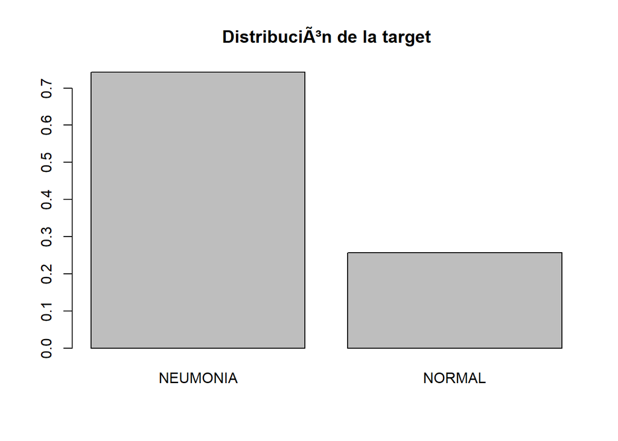

```r
target_ <- ifelse(train_generator$classes == 0, CLASE_0, CLASE_1)
barplot(prop.table(table(target_)), main = 'DistribuciÃ³n de la target')
```

- Vamos a observar algunas imágenes

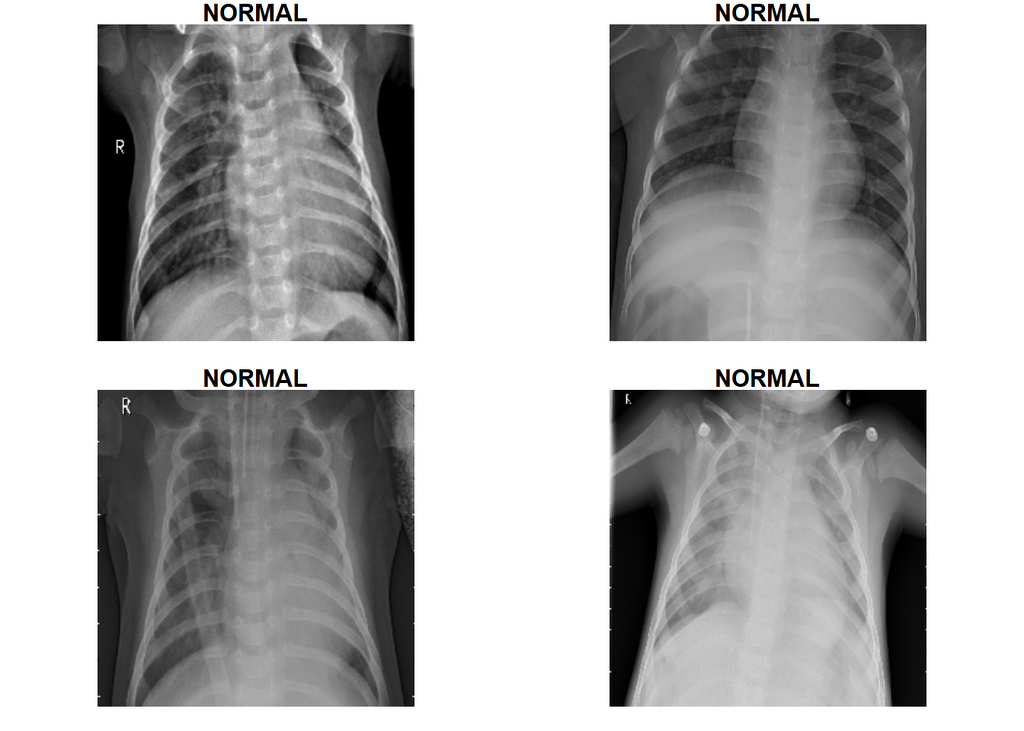

```r
datagen_plot <- image_data_generator(rescale = 1/255.)
image_generator <- flow_images_from_directory(PATH_TRAIN, datagen_plot)

op <- par(mfrow = c(2, 2), pty = "s", mar = c(1, 0, 1, 0))
for (i in 1:4) {
  batch <- generator_next(image_generator)
  plot(as.raster(batch[[1]][1,,,]))
  title(ifelse(batch[[2]][1] == 0, CLASE_0, CLASE_1))
}
```

```r
par(op)
```

### Entrenando el modelo

Vamos a usar como modelo preentrenado InceptionV3.

Vamos a congelar todas las capas menos la última, que será de tamaño 1, el cual indica la salida (0 si es NORMAL, 1 si es NEUMONIA)

```r
conv_base <- application_inception_v3(
  weights = "imagenet",
  include_top = FALSE,
  pooling = 'avg'
  )

freeze_weights(conv_base)

model <- keras_model_sequential() %>%
  conv_base %>%
  layer_batch_normalization() %>%
  layer_dropout(0.5) %>%
  layer_dense(1, activation = 'sigmoid')

model %>% summary()
```

```
## ___________________________________________________________________________
## Layer (type)                     Output Shape                  Param #
## ===========================================================================
## inception_v3 (Model)             (None, 2048)                  21802784
## ___________________________________________________________________________
## batch_normalization_95 (BatchNor (None, 2048)                  8192
## ___________________________________________________________________________
## dropout_1 (Dropout)              (None, 2048)                  0
## ___________________________________________________________________________
## dense_1 (Dense)                  (None, 1)                     2049
## ===========================================================================
## Total params: 21,813,025
## Trainable params: 6,145
## Non-trainable params: 21,806,880
## ___________________________________________________________________________
```

```r
model %>% compile(optimizer = optimizer_adam(lr=0.001),
                  loss = 'binary_crossentropy',
                  metrics = c('accuracy'))
```

Entrenando en el conjunto de entrenamiento

```r
model %>% fit_generator(train_generator,
                        epochs = 1,
                        steps_per_epoch = train_generator$n / BATCH_SIZE)
```

Luego de haber entrenado en pocas iteraciones, vamos a descongelar todas las capas y entrenar de nuevo. Esta vez usando un conjunto de validación y realizando una parada temprana, esto para evitar el sobreajuste

```r
# Agregando una regularizaciÃ³n y descongelando las capas
for (layer in model$layers){
  layer$W_regularizer <- regularizer_l2(1e-3)
  layer$trainable <- TRUE
}

model %>% compile(optimizer = optimizer_adam(lr=1e-4, decay = 1e-5),
                  loss = 'binary_crossentropy',
                  metrics = c('accuracy'))

model %>% summary()
```

```
## ___________________________________________________________________________
## Layer (type)                     Output Shape                  Param #
## ===========================================================================
## inception_v3 (Model)             (None, 2048)                  21802784
## ___________________________________________________________________________
## batch_normalization_95 (BatchNor (None, 2048)                  8192
## ___________________________________________________________________________
## dropout_1 (Dropout)              (None, 2048)                  0
## ___________________________________________________________________________
## dense_1 (Dense)                  (None, 1)                     2049
## ===========================================================================
## Total params: 21,813,025
## Trainable params: 21,774,497
## Non-trainable params: 38,528
## ___________________________________________________________________________
```

```r
# Agregando checkpoint de parada y guardar el mejor modelo
checkpointer <- callback_model_checkpoint(filepath = FILE_MODEL, verbose = 1, save_best_only = TRUE)
earlyStopping <- callback_early_stopping(monitor = 'val_loss', patience = 10, verbose = 2,
                                         mode = 'auto', min_delta = 1e-4)
```

Entrenando el modelo y validándolo en el conjunto de validación

```r
# Entrenando el modelo
model %>% fit_generator(train_generator,
                        epochs = 2,
                        steps_per_epoch = train_generator$n / BATCH_SIZE,
                        validation_data = val_generator,
                        validation_steps = val_generator$n / BATCH_SIZE,
                        callbacks = list(checkpointer, earlyStopping),
                        initial_epoch = 1)
```

### Probando en test

Ahora vamos a leer el mejor modelo y probarlo en el conjunto de test

```r
best_model <- load_model_hdf5(FILE_MODEL)
```

Prediciendo en test

```r
pred_test <- best_model %>% predict_generator(test_generator,
                                              steps = test_generator$n / BATCH_SIZE,
                                              verbose=1)
class_test <- test_generator$classes
class_predict <- as.numeric(pred_test > 0.5)
```

Evaluando en test

```r
caret::confusionMatrix(as.factor(class_test), as.factor(class_predict))
```

```
## Confusion Matrix and Statistics
##
##           Reference
## Prediction   0   1
##          0  49 185
##          1   0 390
##
##                Accuracy : 0.7035
##                  95% CI : (0.666, 0.7391)
##     No Information Rate : 0.9215
##     P-Value [Acc > NIR] : 1
##
##                   Kappa : 0.2487
##  Mcnemar's Test P-Value : <2e-16
##
##             Sensitivity : 1.00000
##             Specificity : 0.67826
##          Pos Pred Value : 0.20940
##          Neg Pred Value : 1.00000
##              Prevalence : 0.07853
##          Detection Rate : 0.07853
##    Detection Prevalence : 0.37500
##       Balanced Accuracy : 0.83913
##
##        'Positive' Class : 0
##
```

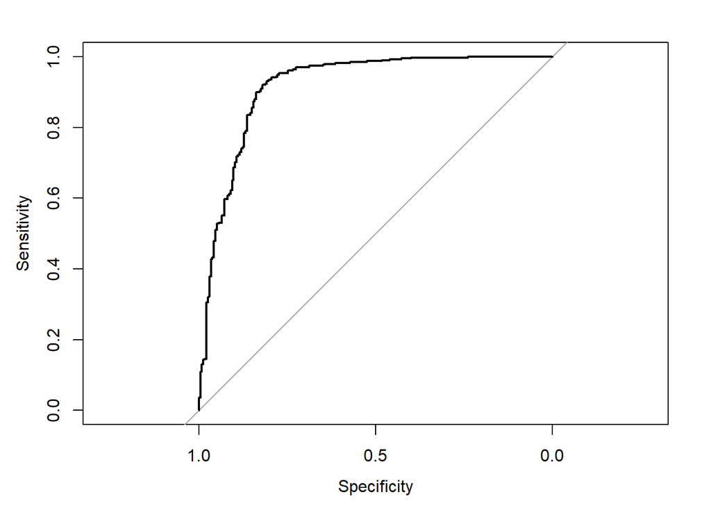

```r
roc_test <- pROC::roc(class_test, as.numeric(pred_test))
plot(roc_test)
```

```r
roc_test
```

```
##
## Call:
## roc.default(response = class_test, predictor = as.numeric(pred_test))
##
## Data: as.numeric(pred_test) in 234 controls (class_test 0) < 390 cases (class_test 1).
## Area under the curve: 0.917
```